# Pertemuan 4

Reyzha Siva Dewi

2023-09-21

### White Noise

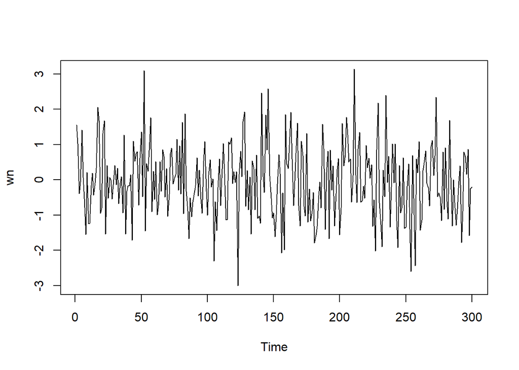

```r
set.seed(1074)
wn <- rnorm(300)
ts.plot(wn)
```

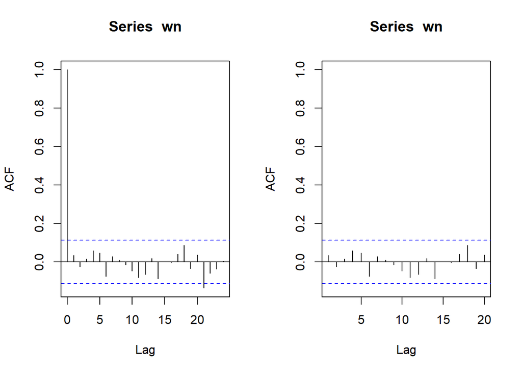

```r
par(mfrow = c(1, 2))
acf(wn)
acf(wn, xlim = c(1, 20))
```

### Proses MA(2)

```r
set.seed(1074)
ma <- wn[1]
ma[1] <- wn[1]
ma[2]<- wn[2]
```

```r
for(i in 3:300){

   ma[i] <- wn[i] + 0.4 * wn[i - 1] + 0.6*wn[i-2]

}

ma
```

```
##   [1]  1.55750186  1.02604911  0.95810788  0.38771305  1.15068394  0.58747443
##   [7]  0.34549480 -1.72082337 -0.73005331 -2.08704520 -1.60325808 -1.39178669
##  [13] -0.60712211 -0.44683704 -0.14100186  0.03704949  2.13815376  2.70980123
##  [19]  0.95680333 -0.17843069  0.41945957  1.71860606 -0.07792249  0.79990775
##  [25] -1.28072436  0.11044255 -0.28814358 -0.50425096 -0.21357807  0.08872238
##  [31]  0.03168600  0.52209687 -0.62909744 -0.15544539 -0.35026872 -0.94987260
##  [37]  0.95162039 -1.59181512 -0.18141590 -1.22886549 -0.43856658 -0.02608413
##  [43] -1.75702839  0.49766764 -0.05915102  1.60774687  1.41315285  0.04326337
##  [49]  0.80820812  1.17715837  0.43600499  3.71980588 -0.50152749  1.73648822
##  [55] -0.43978829  1.20430081  2.23964533  0.29771591  0.93918889 -0.99309769
##  [61]  0.44771565 -1.11125660 -0.80772086 -0.36500513 -0.55508574  1.04058606
##  [67]  0.82083370  0.29669323  0.52385995 -1.19758803 -0.63181882 -0.03312208
##  [73]  0.94903737  0.68912898  0.51315095  0.09566582  1.22630899  0.26666146
##  [79]  1.53856151 -0.18510359  2.05629984 -0.54135229  2.47288034 -0.15380294
##  [85]  0.10698509 -2.22462992 -1.71584614 -2.26023755 -1.35554540 -1.24664930
```

[output cut: 35 more lines]

Selain menggunakan cara di atas, pembangkitan proses MA(2) dapat dilakukan dengan fungsi `arima.sim()` sebagai berikut.

```r
ma2 <- arima.sim(list(order=c(0,0,2), ma=c(0.4,0.6)), n=300)
```

### Karakteristik MA(2)

#### Plot Time Series

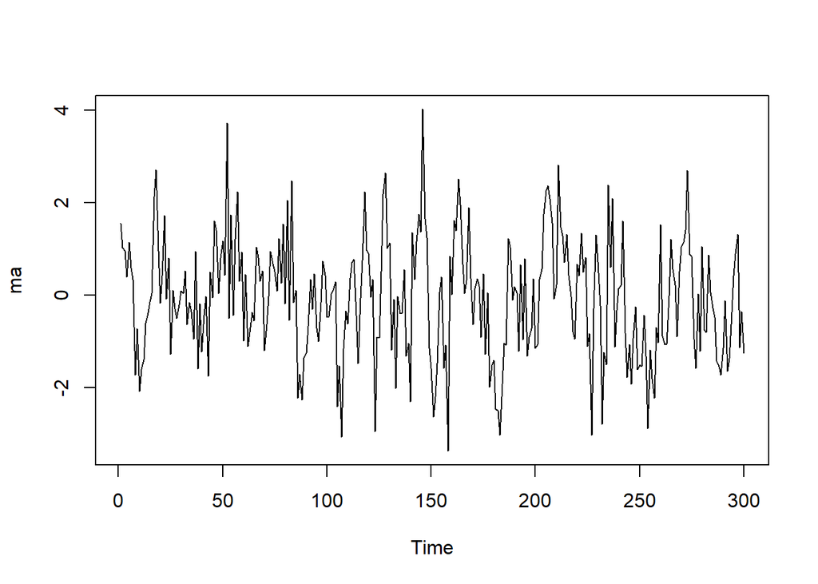

```r
ts.plot(ma)
```

Berdasarkan plot time series, terlihat bahwa data MA(2) yang dibangkitkan stasioner dalam rataan

#### Plot ACF

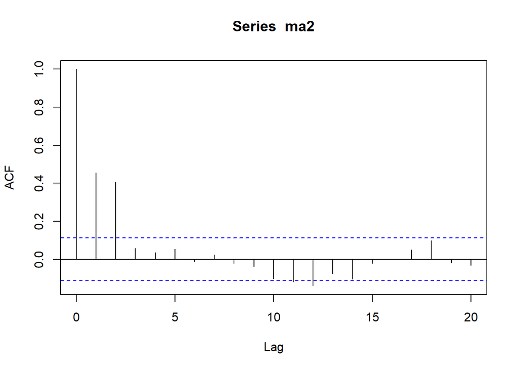

```r
acf(ma2,lag.max = 20)
```

Berdasarkan plot AFC tersebut, terlihat bahwa plot ACF *cuts off* di lag kedua

#### Plot PACF

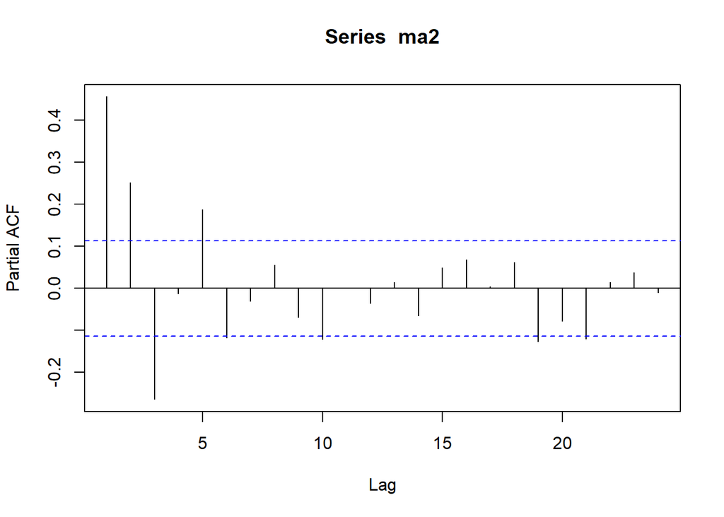

```r
pacf(ma2)
```

Berdasarkan plot PACF tersebut, terlihat bahwa plot PACF cenderung *tails off*

#### Plot EACF

```r
TSA::eacf(ma2)
```

```
## AR/MA
##   0 1 2 3 4 5 6 7 8 9 10 11 12 13
## 0 x x o o o o o o o o x  x  o  o
## 1 x x x o o o o o o o o  o  o  o
## 2 x x x x o o o o o o o  o  o  o
## 3 o x o o o o o o o o o  o  o  o
## 4 o x x o o o o o o o o  o  o  o
## 5 x x x o o o x o o o o  o  o  o
## 6 x x x o o o o o o o o  o  o  o
## 7 x o x o x x o o x o o  o  o  o
```

Berdasarkan pola segitiga nol pada plot EACF, terlihat bahwa segitiga nol berada pada ordo AR(0) dan ordo MA(2)

### Scatterplot Antar Lag

#### Korelasi antara $Y_t$ dengan $Y_{t-1}$

```r
yt_ma <- ma2[-1]

yt_ma
```

[output not shown]

[output cut: 35 more lines]

```r
#Yt-1

yt_1_ma <- ma2[-300]

yt_1_ma
```

[output not shown]

[output cut: 35 more lines]

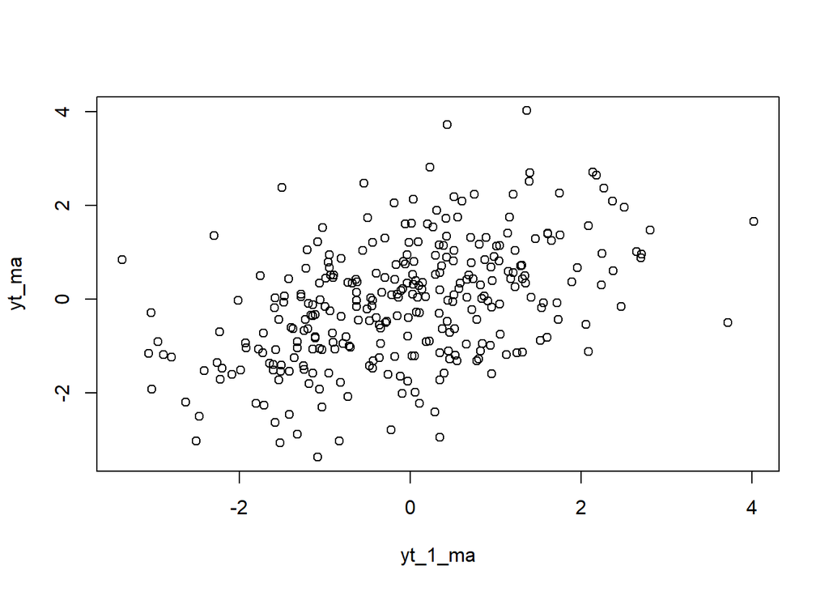

```r
plot(y=yt_ma,x=yt_1_ma)
```

Berdasarkan scatterplot tersebut, terlihat bahwa terdapat hubungan positif antara $Y_t$ dengan $Y_{t-1}$. Hal ini sesuai dengan teori yang ada

```r
cor(yt_ma,yt_1_ma)
```

```
## [1] 0.4569004
```

Korelasi antara $Y_t$ dengan $Y_{t-1}$ dari hasil simulasi mendekati perhitungan teoritis yaitu 0.421053

#### Korelasi antara $Y_t$ dengan $Y_{t-2}$

```r
#Yt

yt_ma2 <- ma[-c(1,2)]

yt_ma2
```

```
##   [1]  0.95810788  0.38771305  1.15068394  0.58747443  0.34549480 -1.72082337
##   [7] -0.73005331 -2.08704520 -1.60325808 -1.39178669 -0.60712211 -0.44683704
##  [13] -0.14100186  0.03704949  2.13815376  2.70980123  0.95680333 -0.17843069
##  [19]  0.41945957  1.71860606 -0.07792249  0.79990775 -1.28072436  0.11044255
##  [25] -0.28814358 -0.50425096 -0.21357807  0.08872238  0.03168600  0.52209687
##  [31] -0.62909744 -0.15544539 -0.35026872 -0.94987260  0.95162039 -1.59181512
##  [37] -0.18141590 -1.22886549 -0.43856658 -0.02608413 -1.75702839  0.49766764
##  [43] -0.05915102  1.60774687  1.41315285  0.04326337  0.80820812  1.17715837
##  [49]  0.43600499  3.71980588 -0.50152749  1.73648822 -0.43978829  1.20430081
##  [55]  2.23964533  0.29771591  0.93918889 -0.99309769  0.44771565 -1.11125660
##  [61] -0.80772086 -0.36500513 -0.55508574  1.04058606  0.82083370  0.29669323
##  [67]  0.52385995 -1.19758803 -0.63181882 -0.03312208  0.94903737  0.68912898
##  [73]  0.51315095  0.09566582  1.22630899  0.26666146  1.53856151 -0.18510359
##  [79]  2.05629984 -0.54135229  2.47288034 -0.15380294  0.10698509 -2.22462992
##  [85] -1.71584614 -2.26023755 -1.35554540 -1.24664930 -0.67738628  0.34215269
```

[output cut: 35 more lines]

```r
#Yt-2

yt_2_ma <- ma[-c(299,300)]

yt_2_ma
```

```
##   [1]  1.55750186  1.02604911  0.95810788  0.38771305  1.15068394  0.58747443
##   [7]  0.34549480 -1.72082337 -0.73005331 -2.08704520 -1.60325808 -1.39178669
##  [13] -0.60712211 -0.44683704 -0.14100186  0.03704949  2.13815376  2.70980123
##  [19]  0.95680333 -0.17843069  0.41945957  1.71860606 -0.07792249  0.79990775
##  [25] -1.28072436  0.11044255 -0.28814358 -0.50425096 -0.21357807  0.08872238
##  [31]  0.03168600  0.52209687 -0.62909744 -0.15544539 -0.35026872 -0.94987260
##  [37]  0.95162039 -1.59181512 -0.18141590 -1.22886549 -0.43856658 -0.02608413
##  [43] -1.75702839  0.49766764 -0.05915102  1.60774687  1.41315285  0.04326337
##  [49]  0.80820812  1.17715837  0.43600499  3.71980588 -0.50152749  1.73648822
##  [55] -0.43978829  1.20430081  2.23964533  0.29771591  0.93918889 -0.99309769
##  [61]  0.44771565 -1.11125660 -0.80772086 -0.36500513 -0.55508574  1.04058606
##  [67]  0.82083370  0.29669323  0.52385995 -1.19758803 -0.63181882 -0.03312208
##  [73]  0.94903737  0.68912898  0.51315095  0.09566582  1.22630899  0.26666146
##  [79]  1.53856151 -0.18510359  2.05629984 -0.54135229  2.47288034 -0.15380294
##  [85]  0.10698509 -2.22462992 -1.71584614 -2.26023755 -1.35554540 -1.24664930
```

[output cut: 35 more lines]

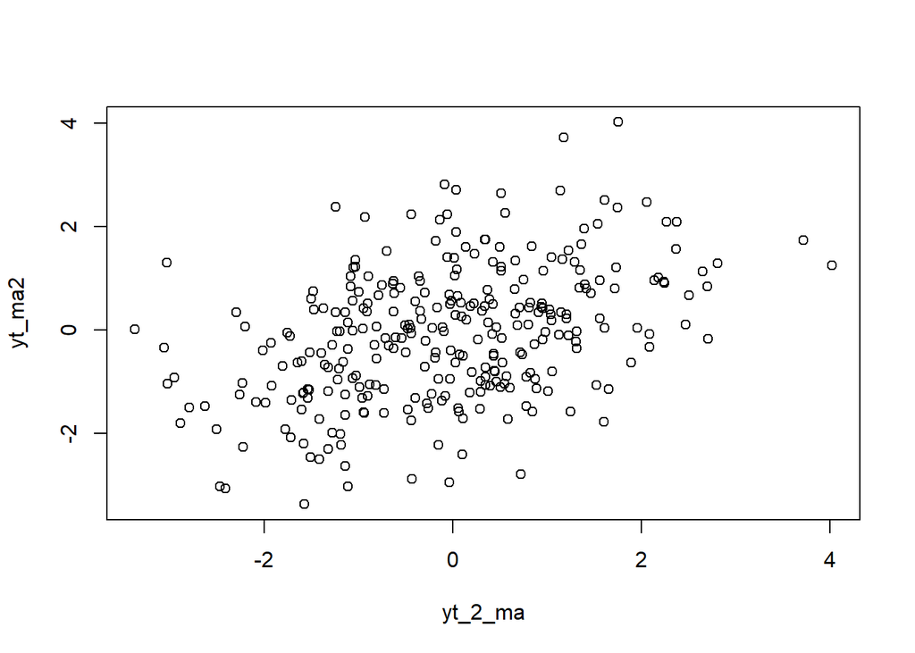

```r
plot(y=yt_ma2,x=yt_2_ma)
```

```r
cor(yt_ma2,yt_2_ma)
```

```
## [1] 0.4133955
```

Korelasi antara $Y_t$ dengan $Y_{t-2}$ hasil simulasi mendekati teori yang ada yaitu 0.394737.

#### Korelasi antara $Y_t$ dengan $Y_{t-3}$

```r
#Yt
yt_ma2 <- ma[-c(1,2,3)]
yt_ma2
```

```
##   [1]  0.38771305  1.15068394  0.58747443  0.34549480 -1.72082337 -0.73005331
##   [7] -2.08704520 -1.60325808 -1.39178669 -0.60712211 -0.44683704 -0.14100186
##  [13]  0.03704949  2.13815376  2.70980123  0.95680333 -0.17843069  0.41945957
##  [19]  1.71860606 -0.07792249  0.79990775 -1.28072436  0.11044255 -0.28814358
##  [25] -0.50425096 -0.21357807  0.08872238  0.03168600  0.52209687 -0.62909744
##  [31] -0.15544539 -0.35026872 -0.94987260  0.95162039 -1.59181512 -0.18141590
##  [37] -1.22886549 -0.43856658 -0.02608413 -1.75702839  0.49766764 -0.05915102
##  [43]  1.60774687  1.41315285  0.04326337  0.80820812  1.17715837  0.43600499
##  [49]  3.71980588 -0.50152749  1.73648822 -0.43978829  1.20430081  2.23964533
##  [55]  0.29771591  0.93918889 -0.99309769  0.44771565 -1.11125660 -0.80772086
##  [61] -0.36500513 -0.55508574  1.04058606  0.82083370  0.29669323  0.52385995
##  [67] -1.19758803 -0.63181882 -0.03312208  0.94903737  0.68912898  0.51315095
##  [73]  0.09566582  1.22630899  0.26666146  1.53856151 -0.18510359  2.05629984
##  [79] -0.54135229  2.47288034 -0.15380294  0.10698509 -2.22462992 -1.71584614
##  [85] -2.26023755 -1.35554540 -1.24664930 -0.67738628  0.34215269 -0.29893082
```

[output cut: 35 more lines]

```r
#Yt-3
yt_3_ma <- ma[-c(298,299,300)]
yt_3_ma
```

```
##   [1]  1.55750186  1.02604911  0.95810788  0.38771305  1.15068394  0.58747443
##   [7]  0.34549480 -1.72082337 -0.73005331 -2.08704520 -1.60325808 -1.39178669
##  [13] -0.60712211 -0.44683704 -0.14100186  0.03704949  2.13815376  2.70980123
##  [19]  0.95680333 -0.17843069  0.41945957  1.71860606 -0.07792249  0.79990775
##  [25] -1.28072436  0.11044255 -0.28814358 -0.50425096 -0.21357807  0.08872238
##  [31]  0.03168600  0.52209687 -0.62909744 -0.15544539 -0.35026872 -0.94987260
##  [37]  0.95162039 -1.59181512 -0.18141590 -1.22886549 -0.43856658 -0.02608413
##  [43] -1.75702839  0.49766764 -0.05915102  1.60774687  1.41315285  0.04326337
##  [49]  0.80820812  1.17715837  0.43600499  3.71980588 -0.50152749  1.73648822
##  [55] -0.43978829  1.20430081  2.23964533  0.29771591  0.93918889 -0.99309769
##  [61]  0.44771565 -1.11125660 -0.80772086 -0.36500513 -0.55508574  1.04058606
##  [67]  0.82083370  0.29669323  0.52385995 -1.19758803 -0.63181882 -0.03312208
##  [73]  0.94903737  0.68912898  0.51315095  0.09566582  1.22630899  0.26666146
##  [79]  1.53856151 -0.18510359  2.05629984 -0.54135229  2.47288034 -0.15380294
##  [85]  0.10698509 -2.22462992 -1.71584614 -2.26023755 -1.35554540 -1.24664930
```

[output cut: 35 more lines]

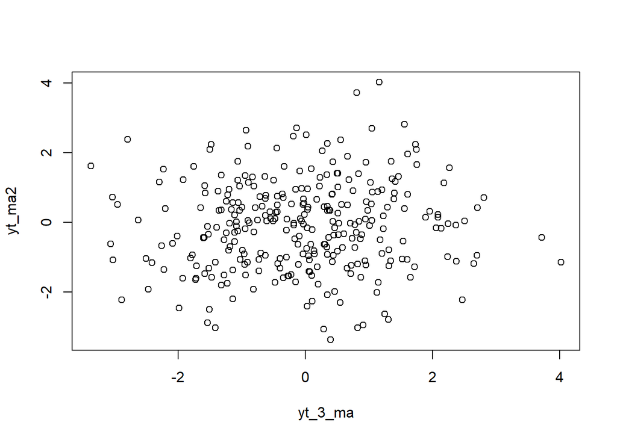

```r
plot(y=yt_ma2,x=yt_3_ma)
```

Berdasarkan scatterplot tersebut, terlihat bahwa cenderung tidak terdapat hubungan antara $Y_t$ dengan $Y_{t-3}$.

```r
cor(yt_ma2,yt_3_ma)
```

```
## [1] 0.06061879
```

Korelasi antara $Y_t$ dengan $Y_t{t-3}$ hasil simulasi mendekati teori yang ada yaitu 0.

## Proses AR

#### Pembangkitan Proses AR

```r
set.seed(1074)
```

```r
n <- length(wn)
n
```

```
## [1] 300
```

```r
ar <- c(1:n)
for (i in 3 :n) {ar[i]<-wn[i]+0.5*ar[i-1]+0.2*ar[i-2]}
ar
```

```
##   [1]  1.000000000  2.000000000  0.813187123  0.733402298  1.941386749
##   [6]  1.183943749  0.451887157 -1.086688163 -0.246234521 -1.580540652
##  [11] -2.070780286 -1.506728289 -0.973792473 -1.219432017 -0.889236947
##  [16] -0.358836333  1.699878252  2.467314441  0.620492887 -0.006950916
##  [21]  1.436230781  2.395484351 -0.053802416  0.860364227 -0.101295711
##  [26]  0.195253336  0.072123009 -0.471337989 -0.213095688  0.212517550
##  [31] -0.074896780  0.334566758 -0.525476222 -0.277865038 -0.154812222
##  [36] -1.069313767  0.707005599 -1.399424252 -0.887676147 -0.897403784
##  [41] -0.797712274 -0.431622442 -2.088182750 -0.035645261  0.095179006
##  [46]  0.779089682  1.207898884  0.040125916  0.878116494  1.809437178
##  [51]  0.601521119  3.756569934  0.546785389  1.485563263  1.099090066
##  [56]  1.675664004  2.817522006  0.840257125  1.228353326  0.233424261
##  [61]  0.882787759 -0.502057559 -0.798380546  0.019038590 -0.478353115
##  [66]  0.625311520  0.890464474  0.081187816  0.534101839 -0.747001527
##  [71] -0.675632233  0.261416237  0.890537079  0.379519011  0.391257736
```

[output cut: 45 more lines]

```r
ar1 <- arima.sim(list(order=c(2,0,0), ar=c(0.5,0.2)),n=300)
ar1
```

```
## Time Series:
## Start = 1
## End = 300
## Frequency = 1
##   [1]  0.195199273  0.072081794 -0.471369409 -0.213119641  0.212499289
##   [6] -0.074910701  0.334556146 -0.525484313 -0.277871205 -0.154816924
##  [11] -1.069317352  0.707002866 -1.399426335 -0.887677736 -0.897404994
##  [16] -0.797713197 -0.431623146 -2.088183287 -0.035645670  0.095178694
##  [21]  0.779089444  1.207898702  0.040125778  0.878116389  1.809437098
##  [26]  0.601521058  3.756569887  0.546785354  1.485563236  1.099090045
##  [31]  1.675663989  2.817521994  0.840257116  1.228353319  0.233424256
##  [36]  0.882787755 -0.502057562 -0.798380549  0.019038588 -0.478353117
##  [41]  0.625311519  0.890464473  0.081187815  0.534101838 -0.747001528
##  [46] -0.675632234  0.261416237  0.890537079  0.379519011  0.391257736
##  [51]  0.428661826  1.442005295  0.519349847  1.511937855  0.461621660
```

[output cut: 49 more lines]

### Karakteristik AR(2)

#### Plot Time Series

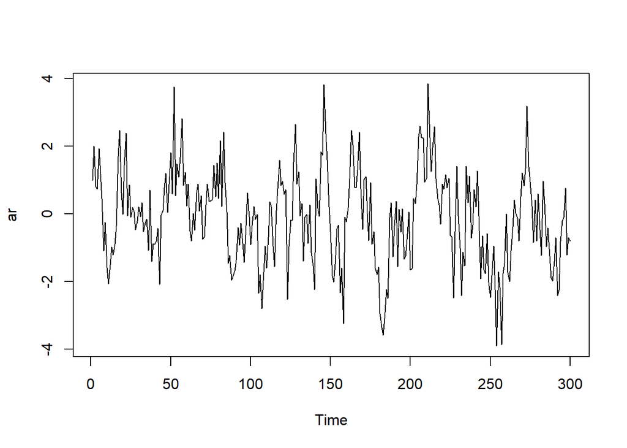

```r
ts.plot(ar)
```

#### Plot ACF

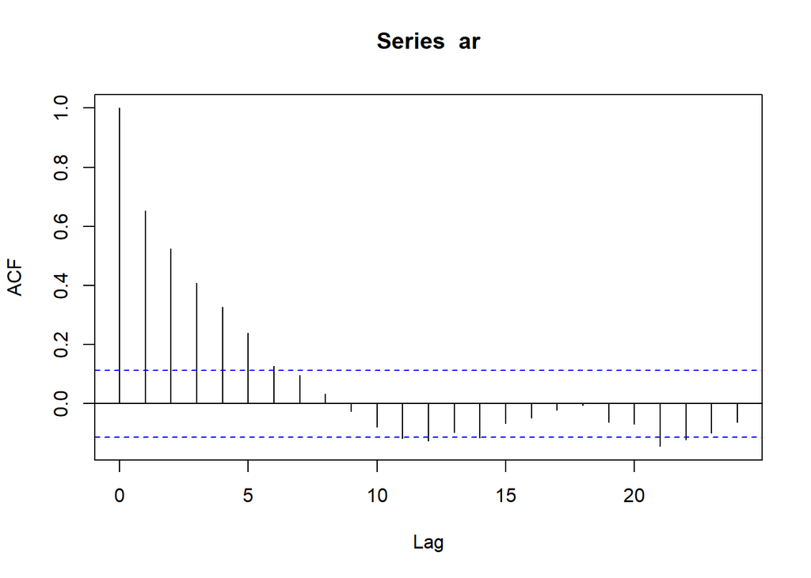

```r
acf(ar)
```

#### Plot PACF

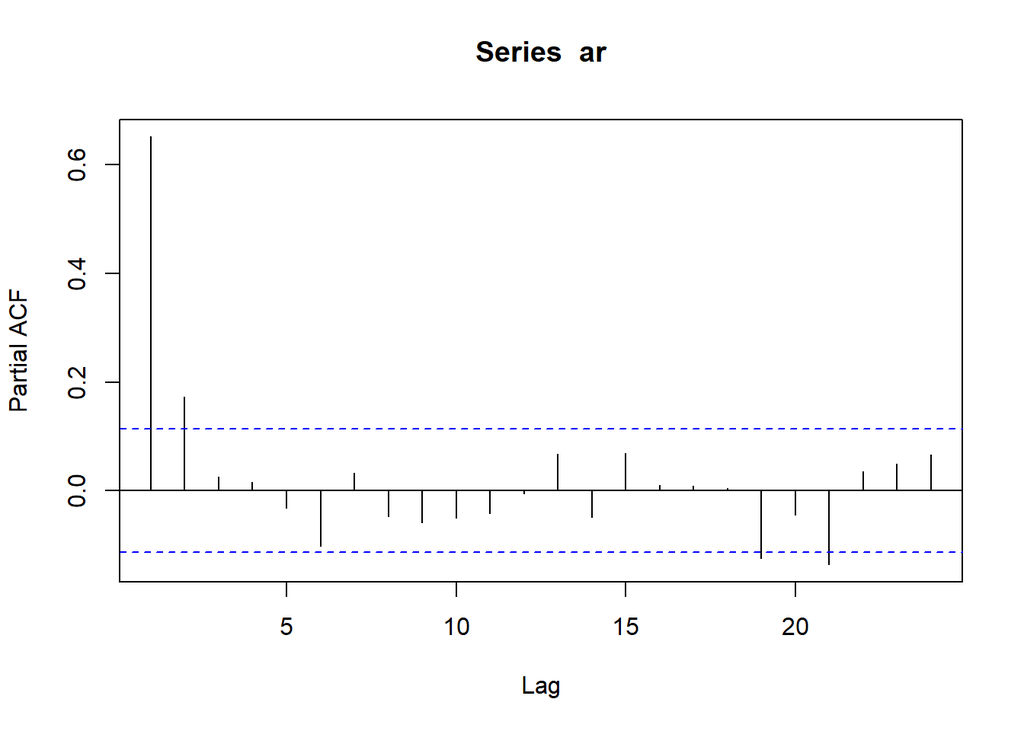

```r
pacf(ar)
```

```r
TSA::eacf(ar)
```

```
## AR/MA
##   0 1 2 3 4 5 6 7 8 9 10 11 12 13
## 0 x x x x x x o o o o o  x  o  o
## 1 x o o o o o o o o o o  o  o  o
## 2 x o o o o o o o o o o  o  o  o
## 3 x o o o o o o o o o o  o  o  o
## 4 x x o o o o o o o o o  o  o  o
## 5 x x o x x o o o o o o  o  o  o
## 6 x x x x o o o o o o o  o  o  o
## 7 x x x x o o x o o o o  o  o  o
```

### Scatterplot Antar Lag

#### Korelasi antara $Y_t$ dengan $Y_{t-1}$

```r
#Yt
yt_ar <- ar[-1]
yt_ar
```

```
##   [1]  2.000000000  0.813187123  0.733402298  1.941386749  1.183943749
##   [6]  0.451887157 -1.086688163 -0.246234521 -1.580540652 -2.070780286
##  [11] -1.506728289 -0.973792473 -1.219432017 -0.889236947 -0.358836333
##  [16]  1.699878252  2.467314441  0.620492887 -0.006950916  1.436230781
##  [21]  2.395484351 -0.053802416  0.860364227 -0.101295711  0.195253336
##  [26]  0.072123009 -0.471337989 -0.213095688  0.212517550 -0.074896780
##  [31]  0.334566758 -0.525476222 -0.277865038 -0.154812222 -1.069313767
##  [36]  0.707005599 -1.399424252 -0.887676147 -0.897403784 -0.797712274
##  [41] -0.431622442 -2.088182750 -0.035645261  0.095179006  0.779089682
##  [46]  1.207898884  0.040125916  0.878116494  1.809437178  0.601521119
##  [51]  3.756569934  0.546785389  1.485563263  1.099090066  1.675664004
##  [56]  2.817522006  0.840257125  1.228353326  0.233424261  0.882787759
##  [61] -0.502057559 -0.798380546  0.019038590 -0.478353115  0.625311520
##  [66]  0.890464474  0.081187816  0.534101839 -0.747001527 -0.675632233
##  [71]  0.261416237  0.890537079  0.379519011  0.391257736  0.428661826
```

[output cut: 45 more lines]

```r
#Yt-1
yt_1_ar <- ar[-300]
yt_1_ar
```

```
##   [1]  1.000000000  2.000000000  0.813187123  0.733402298  1.941386749
##   [6]  1.183943749  0.451887157 -1.086688163 -0.246234521 -1.580540652
##  [11] -2.070780286 -1.506728289 -0.973792473 -1.219432017 -0.889236947
##  [16] -0.358836333  1.699878252  2.467314441  0.620492887 -0.006950916
##  [21]  1.436230781  2.395484351 -0.053802416  0.860364227 -0.101295711
##  [26]  0.195253336  0.072123009 -0.471337989 -0.213095688  0.212517550
##  [31] -0.074896780  0.334566758 -0.525476222 -0.277865038 -0.154812222
##  [36] -1.069313767  0.707005599 -1.399424252 -0.887676147 -0.897403784
##  [41] -0.797712274 -0.431622442 -2.088182750 -0.035645261  0.095179006
##  [46]  0.779089682  1.207898884  0.040125916  0.878116494  1.809437178
##  [51]  0.601521119  3.756569934  0.546785389  1.485563263  1.099090066
##  [56]  1.675664004  2.817522006  0.840257125  1.228353326  0.233424261
##  [61]  0.882787759 -0.502057559 -0.798380546  0.019038590 -0.478353115
##  [66]  0.625311520  0.890464474  0.081187816  0.534101839 -0.747001527
##  [71] -0.675632233  0.261416237  0.890537079  0.379519011  0.391257736
```

[output cut: 45 more lines]

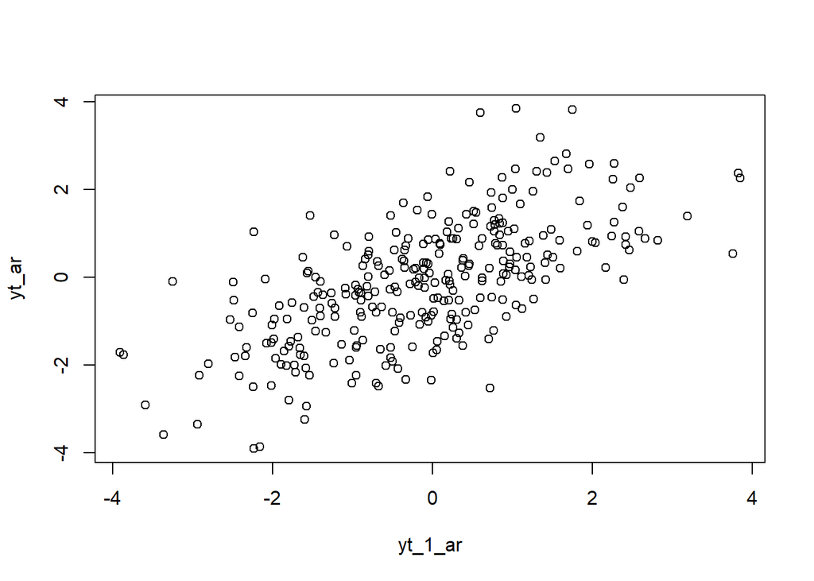

```r
plot(y=yt_ar,x=yt_1_ar)
```

Berdasarkan scatterplot tersebut, terlihat bahwa cenderung memiliki hubungan positif antara $Y_t$ dengan $Y_{t-1}$.

```r
cor(yt_ar, yt_1_ar)
```

```
## [1] 0.6529895
```

Korelasi antara $Y_t$ dengan $Y_{t-1}$ hasil simulasi mendekati teori yang ada yaitu 0.625.

#### Korelasi antara $Y_t$ dengan $Y_{t-2}$

```r
#Yt
yt_ar2 <- ar[-c(1,2)]
yt_ar2
```

```
##   [1]  0.813187123  0.733402298  1.941386749  1.183943749  0.451887157
##   [6] -1.086688163 -0.246234521 -1.580540652 -2.070780286 -1.506728289
##  [11] -0.973792473 -1.219432017 -0.889236947 -0.358836333  1.699878252
##  [16]  2.467314441  0.620492887 -0.006950916  1.436230781  2.395484351
##  [21] -0.053802416  0.860364227 -0.101295711  0.195253336  0.072123009
##  [26] -0.471337989 -0.213095688  0.212517550 -0.074896780  0.334566758
##  [31] -0.525476222 -0.277865038 -0.154812222 -1.069313767  0.707005599
##  [36] -1.399424252 -0.887676147 -0.897403784 -0.797712274 -0.431622442
##  [41] -2.088182750 -0.035645261  0.095179006  0.779089682  1.207898884
##  [46]  0.040125916  0.878116494  1.809437178  0.601521119  3.756569934
##  [51]  0.546785389  1.485563263  1.099090066  1.675664004  2.817522006
##  [56]  0.840257125  1.228353326  0.233424261  0.882787759 -0.502057559
##  [61] -0.798380546  0.019038590 -0.478353115  0.625311520  0.890464474
##  [66]  0.081187816  0.534101839 -0.747001527 -0.675632233  0.261416237
##  [71]  0.890537079  0.379519011  0.391257736  0.428661826  1.442005295
```

[output cut: 45 more lines]

```r
#Yt-2
yt_2_ar <- ar[-c(299,300)]
yt_2_ar
```

```
##   [1]  1.000000000  2.000000000  0.813187123  0.733402298  1.941386749
##   [6]  1.183943749  0.451887157 -1.086688163 -0.246234521 -1.580540652
##  [11] -2.070780286 -1.506728289 -0.973792473 -1.219432017 -0.889236947
##  [16] -0.358836333  1.699878252  2.467314441  0.620492887 -0.006950916
##  [21]  1.436230781  2.395484351 -0.053802416  0.860364227 -0.101295711
##  [26]  0.195253336  0.072123009 -0.471337989 -0.213095688  0.212517550
##  [31] -0.074896780  0.334566758 -0.525476222 -0.277865038 -0.154812222
##  [36] -1.069313767  0.707005599 -1.399424252 -0.887676147 -0.897403784
##  [41] -0.797712274 -0.431622442 -2.088182750 -0.035645261  0.095179006
##  [46]  0.779089682  1.207898884  0.040125916  0.878116494  1.809437178
##  [51]  0.601521119  3.756569934  0.546785389  1.485563263  1.099090066
##  [56]  1.675664004  2.817522006  0.840257125  1.228353326  0.233424261
##  [61]  0.882787759 -0.502057559 -0.798380546  0.019038590 -0.478353115
##  [66]  0.625311520  0.890464474  0.081187816  0.534101839 -0.747001527
##  [71] -0.675632233  0.261416237  0.890537079  0.379519011  0.391257736
```

[output cut: 45 more lines]

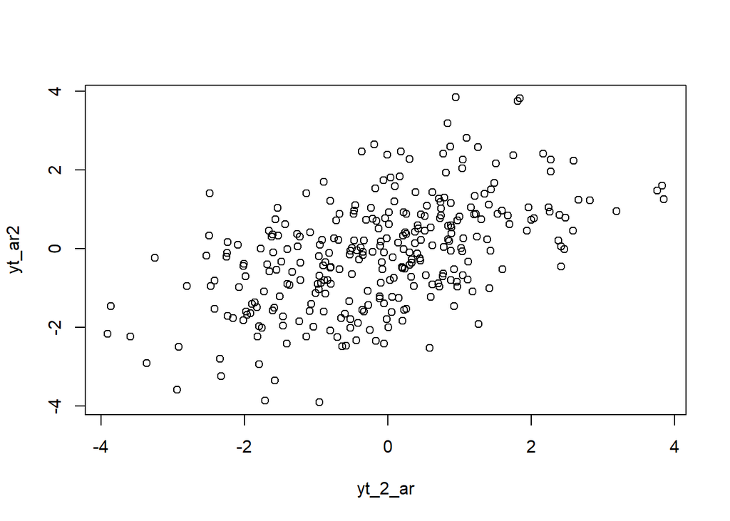

```r
plot(y=yt_ar2,x=yt_2_ar)
```

Berdasarkan scatterplot tersebut, terlihat bahwa cenderung memiliki hubungan positif antara $Y_t$ dengan $Y_{t-2}$.

```r
cor(yt_ar2,yt_2_ar)
```

```
## [1] 0.5271866
```

Korelasi antara $Y_t$ dengan $Y_{t-2}$ sil simulasi mendekati teori yang ada yaitu 0.5125.

```r
#Yt
yt_ar3 <- ar[-c(1,2,3)]
yt_ar3
```

```
##   [1]  0.733402298  1.941386749  1.183943749  0.451887157 -1.086688163
##   [6] -0.246234521 -1.580540652 -2.070780286 -1.506728289 -0.973792473
##  [11] -1.219432017 -0.889236947 -0.358836333  1.699878252  2.467314441
##  [16]  0.620492887 -0.006950916  1.436230781  2.395484351 -0.053802416
##  [21]  0.860364227 -0.101295711  0.195253336  0.072123009 -0.471337989
##  [26] -0.213095688  0.212517550 -0.074896780  0.334566758 -0.525476222
##  [31] -0.277865038 -0.154812222 -1.069313767  0.707005599 -1.399424252
##  [36] -0.887676147 -0.897403784 -0.797712274 -0.431622442 -2.088182750
##  [41] -0.035645261  0.095179006  0.779089682  1.207898884  0.040125916
##  [46]  0.878116494  1.809437178  0.601521119  3.756569934  0.546785389
##  [51]  1.485563263  1.099090066  1.675664004  2.817522006  0.840257125
##  [56]  1.228353326  0.233424261  0.882787759 -0.502057559 -0.798380546
##  [61]  0.019038590 -0.478353115  0.625311520  0.890464474  0.081187816
##  [66]  0.534101839 -0.747001527 -0.675632233  0.261416237  0.890537079
##  [71]  0.379519011  0.391257736  0.428661826  1.442005295  0.519349847
```

[output cut: 45 more lines]

```r
#Yt-3
yt_3_ar <- ar[-c(298,299,300)]
yt_3_ar
```

```
##   [1]  1.000000000  2.000000000  0.813187123  0.733402298  1.941386749
##   [6]  1.183943749  0.451887157 -1.086688163 -0.246234521 -1.580540652
##  [11] -2.070780286 -1.506728289 -0.973792473 -1.219432017 -0.889236947
##  [16] -0.358836333  1.699878252  2.467314441  0.620492887 -0.006950916
##  [21]  1.436230781  2.395484351 -0.053802416  0.860364227 -0.101295711
##  [26]  0.195253336  0.072123009 -0.471337989 -0.213095688  0.212517550
##  [31] -0.074896780  0.334566758 -0.525476222 -0.277865038 -0.154812222
##  [36] -1.069313767  0.707005599 -1.399424252 -0.887676147 -0.897403784
##  [41] -0.797712274 -0.431622442 -2.088182750 -0.035645261  0.095179006
##  [46]  0.779089682  1.207898884  0.040125916  0.878116494  1.809437178
##  [51]  0.601521119  3.756569934  0.546785389  1.485563263  1.099090066
##  [56]  1.675664004  2.817522006  0.840257125  1.228353326  0.233424261
##  [61]  0.882787759 -0.502057559 -0.798380546  0.019038590 -0.478353115
##  [66]  0.625311520  0.890464474  0.081187816  0.534101839 -0.747001527
##  [71] -0.675632233  0.261416237  0.890537079  0.379519011  0.391257736
```

[output cut: 45 more lines]

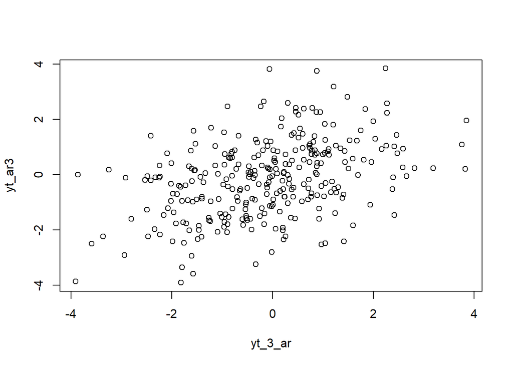

```r
plot(y=yt_ar3,x=yt_3_ar)
```

Berdasarkan scatterplot tersebut, terlihat bahwa cenderung memiliki hubungan positif antara $Y_t$ dengan $Y_{t-3}$.

```r
cor(yt_ar3,yt_3_ar)
```

```
## [1] 0.4122453
```

### Fungsi Pembangkitan ARMA

```r
set.seed(1074)
coefs <- c(0.5, 0.2)
e <- c(0.4, 0.6)

coefs %*% e
```

```
##      [,1]
## [1,] 0.32
```

#### Pembangkitan Fungsi

```r
arma.sim <- function(n, macoef, arcoef){
  manum <- length(macoef)
  arnum <- length(arcoef)
  stopifnot(manum < n & arnum < n)

  wn <- rnorm(n, sd = 0.5)
  init <- max(manum, arnum)

  arma <- wn[1:init]
  for(i in {init+1}:n){
   mastart <- i - manum
   maend <- i-1
   arstart <- i - arnum
   arend <- i-1
   arma[i] <- sum(arcoef * arma[arstart:arend]) + sum(macoef * wn[mastart:maend])  + wn[i]
   }
  return(arma)
}
```

```r
set.seed(1074)
n = length(wn)
phi1 = 0.5
theta1 = 0.4
phi2 = 0.2
theta2 = 0.6

y.arma=c(1:n)
for (i in 3:n){y.arma[i] = phi1*y.arma[i-1] + theta1*wn[i-1]+phi2*y.arma[i-2]+theta2*wn[i-2]+wn[i]}
```

Pembangkitan ARMA(p,q) juga dapat dilakukan dengan fungsi `arima.sim` sebagai berikut

```r
arma11 <- arima.sim(list(order=c(2,0,2), ar = c(0.5,0.2), ma =c(0.4,0.6)), n=300)
arma11
```

```
## Time Series:
## Start = 1
## End = 300
## Frequency = 1
##   [1] -0.327238107 -0.359806547 -0.156628518 -0.118589566  0.431476379
##   [6] -0.437077164 -0.287688700 -0.581528500 -1.298174589  0.186227398
##  [11] -1.758336335 -1.023338592 -2.092202058 -1.689335329 -1.289192201
##  [16] -2.739491552 -1.129916573 -1.172007614  0.795759746  1.576631196
##  [21]  0.990730920  1.618899819  2.184754468  1.852162183  5.082837865
##  [26]  2.410323882  3.958217739  2.021385354  3.006637035  4.147240920
##  [31]  2.972663776  3.254968957  1.228919544  1.713169213 -0.008888086
##  [36] -0.469531057 -0.601548273 -0.949766090  0.445393365  0.853577165
##  [41]  0.812560481  1.100855622 -0.484648124 -0.653971757 -0.457037585
##  [46]  0.589724224  0.892583578  1.077387582  0.812876322  1.848224664
##  [51]  1.353349058  2.584880969  1.378006709  3.262279386  1.365388745
```

[output cut: 49 more lines]

#### Karakteristik ARMA(2,2)

#### Plot Time Series

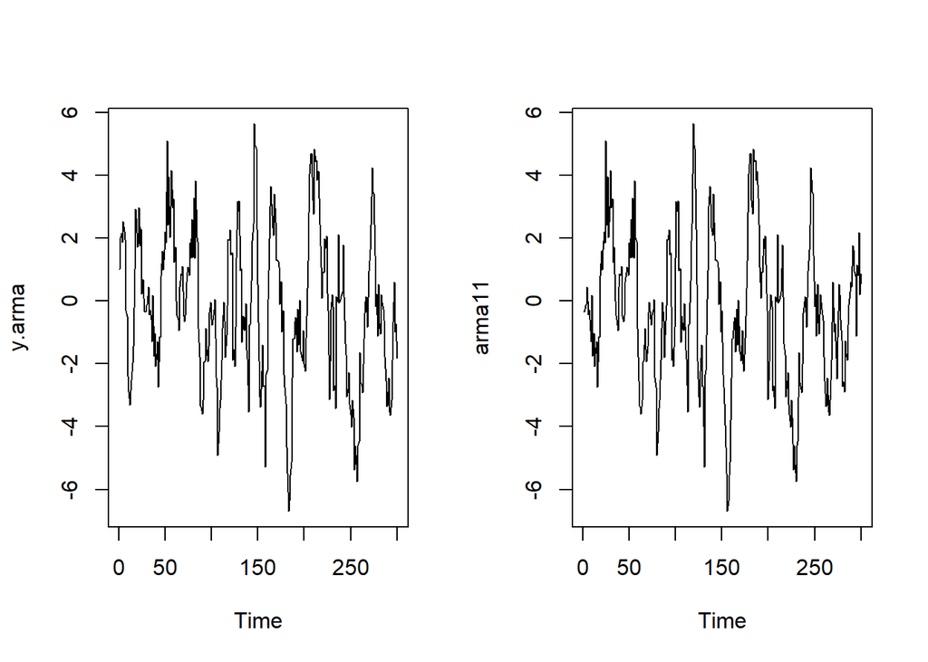

```r
par(mfrow = c(1, 2))
ts.plot(y.arma)
ts.plot(arma11)
```

Berdasarkan plot time series tersebut, terlihat bahwa model ARMA(2,2) cenderung stasioner dalam rataan

#### Plot ACF

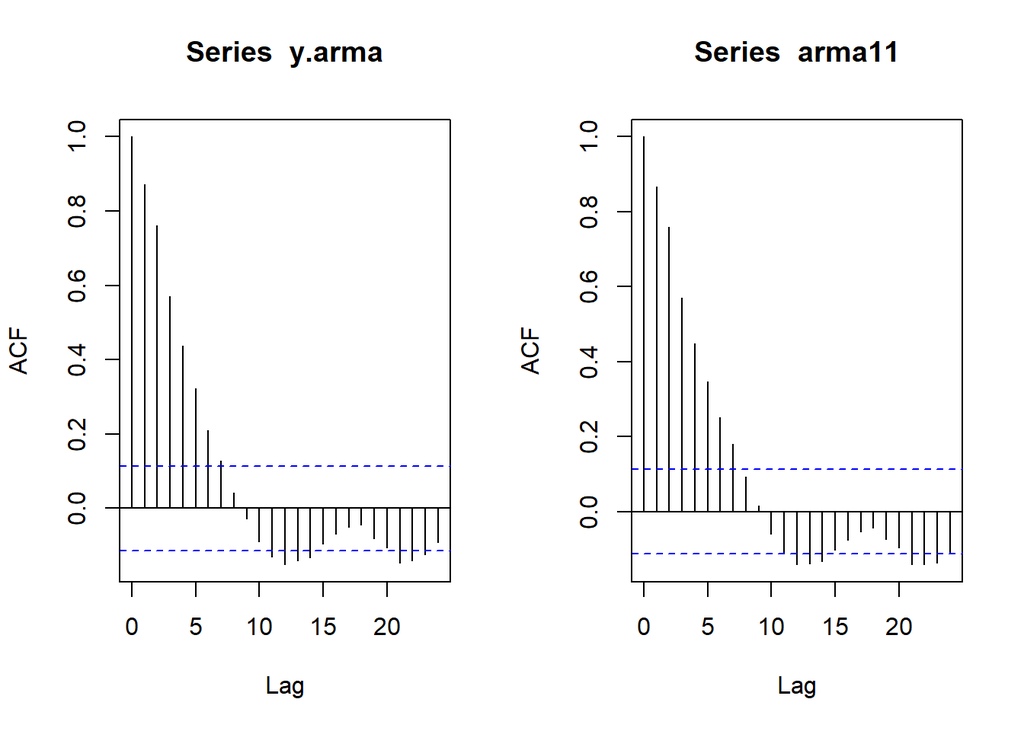

```r
par(mfrow = c(1, 2))
acf(y.arma)
acf(arma11)
```

Berdasarkan plot ACF tersebut, terlihat bahwa model ARMA(2,2) hasil simulasi memiliki plot ACF yang *tails off*, sesuai dengan teori yang ada

#### Plot PACF

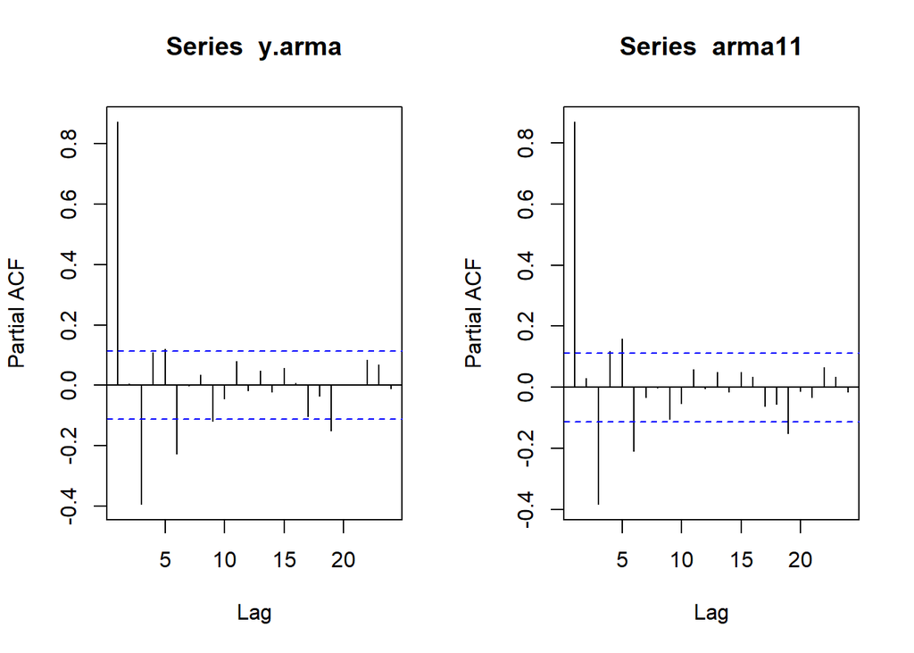

```r
par(mfrow = c(1, 2))
pacf(y.arma)
pacf(arma11)
```

Berdasarkan plot PACF tersebut, terlihat bahwa model ARMA(2,2) hasil simulasi memiliki plot PACF yang *tails off*, sesuai dengan teori

#### Plot EACF

```r
TSA::eacf(y.arma)
```

```
## AR/MA
##   0 1 2 3 4 5 6 7 8 9 10 11 12 13
## 0 x x x x x x x o o o x  x  x  x
## 1 o x o o x o o o o o o  x  o  o
## 2 o x x o o o o o o o o  x  o  o
## 3 x x x x x o o o o o o  o  o  o
## 4 x x x x o o o o o o o  o  o  x
## 5 x x x x o o o o o o o  o  o  o
## 6 o x x o o o o o o o o  o  o  o
## 7 x o x o x x o o o o o  o  o  o
```

```r
TSA::eacf(arma11)
```

```
## AR/MA
##   0 1 2 3 4 5 6 7 8 9 10 11 12 13
## 0 x x x x x x x o o o o  x  x  x
## 1 o x o o o o x o o o o  x  o  o
## 2 o x o o o o x o o o o  x  o  o
## 3 x x o x o o o o o o o  o  o  o
## 4 x x x x o o o o o o o  o  o  o
## 5 x x x x o o o o o o o  o  o  o
## 6 x o x o x x x o o o o  o  o  o
## 7 o o x o x o o o x o o  o  o  o
```

#### **Korelasi antara** $Y_t$ dengan $Y_{t-1}$

```r
#Yt
yt_arma <- arma11[-1]
yt_arma
```

```
##   [1] -0.359806547 -0.156628518 -0.118589566  0.431476379 -0.437077164
##   [6] -0.287688700 -0.581528500 -1.298174589  0.186227398 -1.758336335
##  [11] -1.023338592 -2.092202058 -1.689335329 -1.289192201 -2.739491552
##  [16] -1.129916573 -1.172007614  0.795759746  1.576631196  0.990730920
##  [21]  1.618899819  2.184754468  1.852162183  5.082837865  2.410323882
##  [26]  3.958217739  2.021385354  3.006637035  4.147240920  2.972663776
##  [31]  3.254968957  1.228919544  1.713169213 -0.008888086 -0.469531057
##  [36] -0.601548273 -0.949766090  0.445393365  0.853577165  0.812560481
##  [41]  1.100855622 -0.484648124 -0.653971757 -0.457037585  0.589724224
##  [46]  0.892583578  1.077387582  0.812876322  1.848224664  1.353349058
##  [51]  2.584880969  1.378006709  3.262279386  1.365388745  3.808030587
##  [56]  2.023290107  1.880236265 -0.879853762 -1.779725769 -3.326071183
##  [61] -3.374526143 -3.599126605 -3.151854813 -1.953600041 -1.906101805
##  [66] -0.878654980 -1.532916427 -1.940622443 -1.441752039 -0.372379694
##  [71] -0.040074801 -0.571948416 -0.758262724 -0.466475810 -0.283539306
```

[output cut: 45 more lines]

```r
#Yt-1
yt_1_arma <- arma11[-300]
yt_1_arma
```

```
##   [1] -0.327238107 -0.359806547 -0.156628518 -0.118589566  0.431476379
##   [6] -0.437077164 -0.287688700 -0.581528500 -1.298174589  0.186227398
##  [11] -1.758336335 -1.023338592 -2.092202058 -1.689335329 -1.289192201
##  [16] -2.739491552 -1.129916573 -1.172007614  0.795759746  1.576631196
##  [21]  0.990730920  1.618899819  2.184754468  1.852162183  5.082837865
##  [26]  2.410323882  3.958217739  2.021385354  3.006637035  4.147240920
##  [31]  2.972663776  3.254968957  1.228919544  1.713169213 -0.008888086
##  [36] -0.469531057 -0.601548273 -0.949766090  0.445393365  0.853577165
##  [41]  0.812560481  1.100855622 -0.484648124 -0.653971757 -0.457037585
##  [46]  0.589724224  0.892583578  1.077387582  0.812876322  1.848224664
##  [51]  1.353349058  2.584880969  1.378006709  3.262279386  1.365388745
##  [56]  3.808030587  2.023290107  1.880236265 -0.879853762 -1.779725769
##  [61] -3.326071183 -3.374526143 -3.599126605 -3.151854813 -1.953600041
##  [66] -1.906101805 -0.878654980 -1.532916427 -1.940622443 -1.441752039
##  [71] -0.372379694 -0.040074801 -0.571948416 -0.758262724 -0.466475810
```

[output cut: 45 more lines]

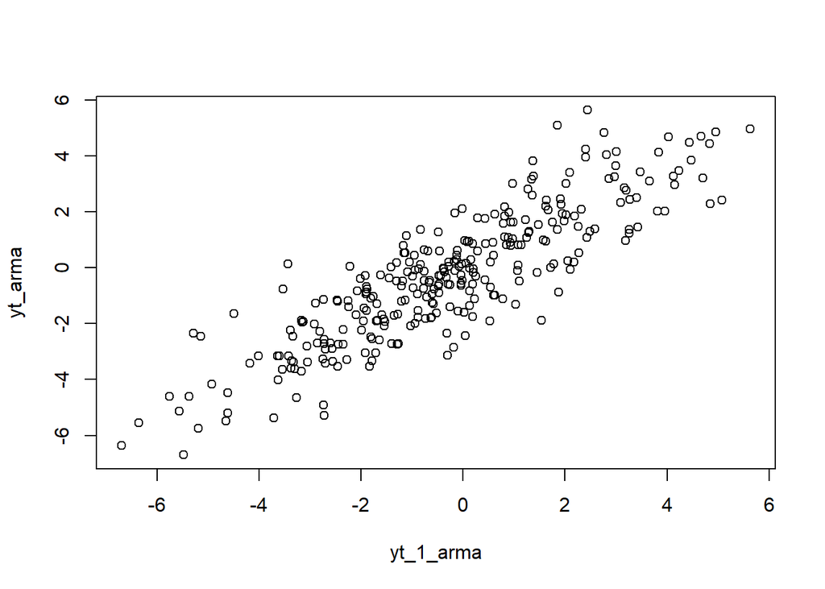

```r
plot(y=yt_arma,x=yt_1_arma)
```

Berdasarkan scatterplot tersebut, terlihat bahwa terdapat hubungan positif antara $Y_t$ dengan $Y_{t−1}$. Hal ini sesuai dengan teori yang ada

```r
cor(yt_arma,yt_1_arma)
```

```
## [1] 0.8676146
```

#### **Korelasi antara** $Y_t$ dengan $Y_{t-2}$

```r
#Yt
yt_arma2 <- arma11[-c(1,2)]
yt_arma2
```

```
##   [1] -0.156628518 -0.118589566  0.431476379 -0.437077164 -0.287688700
##   [6] -0.581528500 -1.298174589  0.186227398 -1.758336335 -1.023338592
##  [11] -2.092202058 -1.689335329 -1.289192201 -2.739491552 -1.129916573
##  [16] -1.172007614  0.795759746  1.576631196  0.990730920  1.618899819
##  [21]  2.184754468  1.852162183  5.082837865  2.410323882  3.958217739
##  [26]  2.021385354  3.006637035  4.147240920  2.972663776  3.254968957
##  [31]  1.228919544  1.713169213 -0.008888086 -0.469531057 -0.601548273
##  [36] -0.949766090  0.445393365  0.853577165  0.812560481  1.100855622
##  [41] -0.484648124 -0.653971757 -0.457037585  0.589724224  0.892583578
##  [46]  1.077387582  0.812876322  1.848224664  1.353349058  2.584880969
##  [51]  1.378006709  3.262279386  1.365388745  3.808030587  2.023290107
##  [56]  1.880236265 -0.879853762 -1.779725769 -3.326071183 -3.374526143
##  [61] -3.599126605 -3.151854813 -1.953600041 -1.906101805 -0.878654980
##  [66] -1.532916427 -1.940622443 -1.441752039 -0.372379694 -0.040074801
##  [71] -0.571948416 -0.758262724 -0.466475810 -0.283539306  0.051704103
```

[output cut: 45 more lines]

```r
#Yt-2
yt_2_arma <- arma11[-c(299,300)]
yt_2_arma
```

```
##   [1] -0.327238107 -0.359806547 -0.156628518 -0.118589566  0.431476379
##   [6] -0.437077164 -0.287688700 -0.581528500 -1.298174589  0.186227398
##  [11] -1.758336335 -1.023338592 -2.092202058 -1.689335329 -1.289192201
##  [16] -2.739491552 -1.129916573 -1.172007614  0.795759746  1.576631196
##  [21]  0.990730920  1.618899819  2.184754468  1.852162183  5.082837865
##  [26]  2.410323882  3.958217739  2.021385354  3.006637035  4.147240920
##  [31]  2.972663776  3.254968957  1.228919544  1.713169213 -0.008888086
##  [36] -0.469531057 -0.601548273 -0.949766090  0.445393365  0.853577165
##  [41]  0.812560481  1.100855622 -0.484648124 -0.653971757 -0.457037585
##  [46]  0.589724224  0.892583578  1.077387582  0.812876322  1.848224664
##  [51]  1.353349058  2.584880969  1.378006709  3.262279386  1.365388745
##  [56]  3.808030587  2.023290107  1.880236265 -0.879853762 -1.779725769
##  [61] -3.326071183 -3.374526143 -3.599126605 -3.151854813 -1.953600041
##  [66] -1.906101805 -0.878654980 -1.532916427 -1.940622443 -1.441752039
##  [71] -0.372379694 -0.040074801 -0.571948416 -0.758262724 -0.466475810
```

[output cut: 45 more lines]

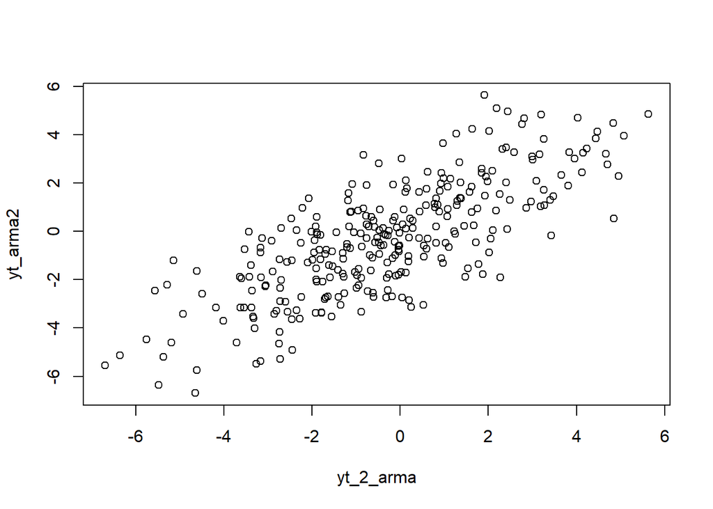

```r
plot(y=yt_arma2,x=yt_2_arma)
```

```r
cor(yt_arma2,yt_2_arma)
```

```
## [1] 0.7601341
```

#### **Korelasi antara** $Y_t$ dengan $Y_{t-3}$

```r
#Yt
yt_arma3 <- arma11[-c(1,2,3)]
yt_arma3
```

```
##   [1] -0.118589566  0.431476379 -0.437077164 -0.287688700 -0.581528500
##   [6] -1.298174589  0.186227398 -1.758336335 -1.023338592 -2.092202058
##  [11] -1.689335329 -1.289192201 -2.739491552 -1.129916573 -1.172007614
##  [16]  0.795759746  1.576631196  0.990730920  1.618899819  2.184754468
##  [21]  1.852162183  5.082837865  2.410323882  3.958217739  2.021385354
##  [26]  3.006637035  4.147240920  2.972663776  3.254968957  1.228919544
##  [31]  1.713169213 -0.008888086 -0.469531057 -0.601548273 -0.949766090
##  [36]  0.445393365  0.853577165  0.812560481  1.100855622 -0.484648124
##  [41] -0.653971757 -0.457037585  0.589724224  0.892583578  1.077387582
##  [46]  0.812876322  1.848224664  1.353349058  2.584880969  1.378006709
##  [51]  3.262279386  1.365388745  3.808030587  2.023290107  1.880236265
##  [56] -0.879853762 -1.779725769 -3.326071183 -3.374526143 -3.599126605
##  [61] -3.151854813 -1.953600041 -1.906101805 -0.878654980 -1.532916427
##  [66] -1.940622443 -1.441752039 -0.372379694 -0.040074801 -0.571948416
##  [71] -0.758262724 -0.466475810 -0.283539306  0.051704103 -2.445434867
```

[output cut: 45 more lines]

```r
#Yt-3
yt_3_arma <- arma11[-c(298,299,300)]
yt_3_arma
```

```
##   [1] -0.327238107 -0.359806547 -0.156628518 -0.118589566  0.431476379
##   [6] -0.437077164 -0.287688700 -0.581528500 -1.298174589  0.186227398
##  [11] -1.758336335 -1.023338592 -2.092202058 -1.689335329 -1.289192201
##  [16] -2.739491552 -1.129916573 -1.172007614  0.795759746  1.576631196
##  [21]  0.990730920  1.618899819  2.184754468  1.852162183  5.082837865
##  [26]  2.410323882  3.958217739  2.021385354  3.006637035  4.147240920
##  [31]  2.972663776  3.254968957  1.228919544  1.713169213 -0.008888086
##  [36] -0.469531057 -0.601548273 -0.949766090  0.445393365  0.853577165
##  [41]  0.812560481  1.100855622 -0.484648124 -0.653971757 -0.457037585
##  [46]  0.589724224  0.892583578  1.077387582  0.812876322  1.848224664
##  [51]  1.353349058  2.584880969  1.378006709  3.262279386  1.365388745
##  [56]  3.808030587  2.023290107  1.880236265 -0.879853762 -1.779725769
##  [61] -3.326071183 -3.374526143 -3.599126605 -3.151854813 -1.953600041
##  [66] -1.906101805 -0.878654980 -1.532916427 -1.940622443 -1.441752039
##  [71] -0.372379694 -0.040074801 -0.571948416 -0.758262724 -0.466475810
```

[output cut: 45 more lines]

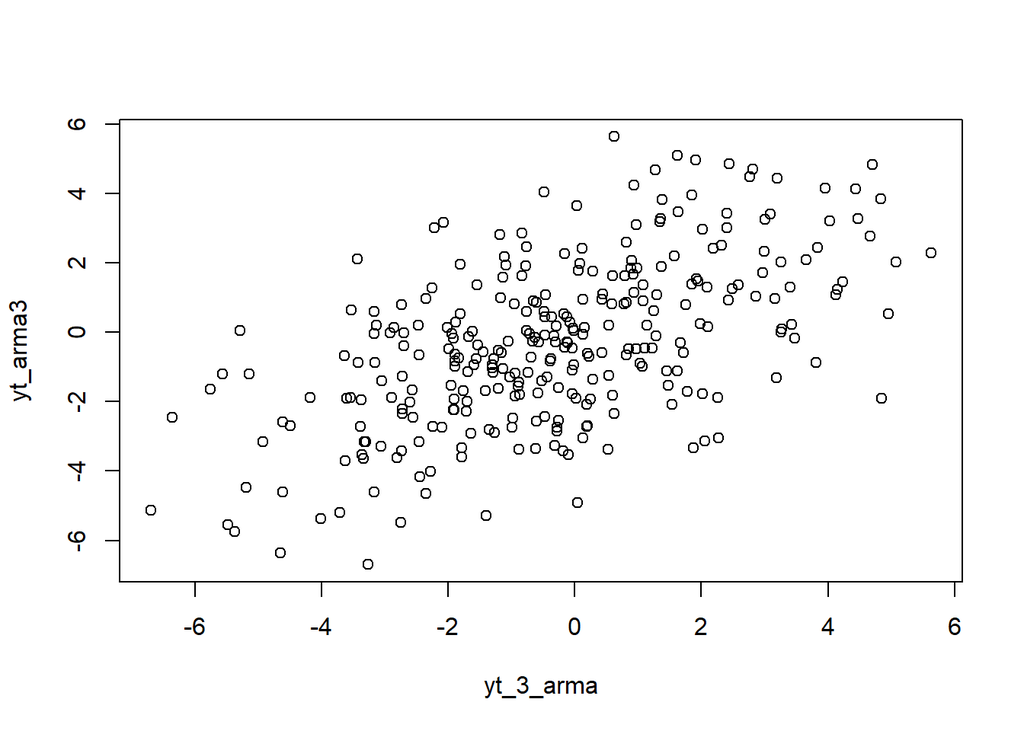

```r
plot(y=yt_arma3,x=yt_3_arma)
```

Berdasarkan scatterplot tersebut, terlihat bahwa terdapat hubungan positif antara $Y_t$ dengan $Y_{t−3}$. Hal ini sesuai dengan teori yang ada

```r
cor(yt_arma3,yt_3_arma)
```

```
## [1] 0.5720936
```